# PART II: Prediction Model

## Objective: To predict the total number of bicycle users on an hourly basis

### Purpose: to help optimizing the bike provisioning and thus optimize the costs incurred from the outsourcing transportation company

```python
data.head().T
```

|  | 0 | 1 | 2 | 3 | 4 |
| --- | --- | --- | --- | --- | --- |
| instant | 1 | 2 | 3 | 4 | 5 |
| dteday | 2011-01-01 | 2011-01-01 | 2011-01-01 | 2011-01-01 | 2011-01-01 |
| season | spring | spring | spring | spring | spring |
| yr | 2011 | 2011 | 2011 | 2011 | 2011 |
| mnth | Jan | Jan | Jan | Jan | Jan |
| hr | 0 | 1 | 2 | 3 | 4 |
| holiday | No | No | No | No | No |
| weekday | Sat | Sat | Sat | Sat | Sat |
| workingday | No | No | No | No | No |
| weathersit | Clear | Clear | Clear | Clear | Clear |
| temp | 0.24 | 0.22 | 0.22 | 0.24 | 0.24 |
| atemp | 0.2879 | 0.2727 | 0.2727 | 0.2879 | 0.2879 |
| hum | 0.81 | 0.8 | 0.8 | 0.75 | 0.75 |
| windspeed | 0.0 | 0.0 | 0.0 | 0.0 | 0.0 |
| casual | 3 | 8 | 5 | 3 | 0 |
| registered | 13 | 32 | 27 | 10 | 1 |
| cnt | 16 | 40 | 32 | 13 | 1 |
| hr_cat | Late Night/Early Morning | Late Night/Early Morning | Late Night/Early Morning | Late Night/Early Morning | Late Night/Early Morning |

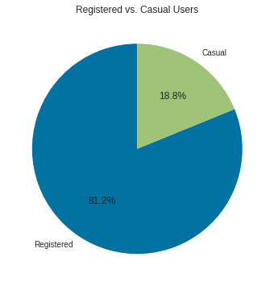

```python
#Pie chart of registered and casual users
fig, ax = plt.subplots(figsize=(10,6))
labels = ['Registered', 'Casual']
ax.pie(data[['registered', 'casual']].sum(), labels=labels, autopct='%1.1f%%', startangle=90)
ax.set_title('Registered vs. Casual Users')
plt.show()
```

#### Deciding between *temp* and *atemp*, *mnth* and *season*

```python
data2.corr()['casual'].abs().sort_values(ascending = False)
```

```
casual                             1.000000
cnt                                0.694564
registered                         0.506618
temp                               0.459616
atemp                              0.454080
hr_cat_Afternoon/Evening           0.441259
hr_cat_Late Night/Early Morning    0.361136
hum                                0.347028
workingday_No                      0.300942
workingday_Yes                     0.300942
season_spring                      0.246476
weekday_Sat                        0.213187
season_fall                        0.175067
weekday_Sun                        0.170408
mnth_Jan                           0.165430
mnth_Feb                           0.143796
yr                                 0.142779
weathersit_Clear                   0.136596
mnth_Dec                           0.130397
season_summer                      0.123983
weathersit_Light Snow              0.118661
mnth_Jul                           0.104571
weekday_Wed                        0.103457
weekday_Tue                        0.099456
mnth_Jun                           0.095392
mnth_May                           0.092592
windspeed                          0.090287
weekday_Thu                        0.089211
mnth_Aug                           0.081310
mnth_Sep                           0.080753
hr_cat_Morning                     0.078610
weathersit_Mist                    0.073386
mnth_Nov                           0.062139
weekday_Mon                        0.058927
season_winter                      0.057646
mnth_Apr                           0.040407
weekday_Fri                        0.034957
mnth_Mar                           0.033971
mnth_Oct                           0.033726
holiday_Yes                        0.031564
holiday_No                         0.031564
weathersit_Heavy Rain              0.008797
hr_cat_Night                       0.004358
Name: casual, dtype: float64
```

```python
data2.corr()['registered'].abs().sort_values(ascending = False)
```

```
registered                         1.000000
cnt                                0.972151
casual                             0.506618
hr_cat_Late Night/Early Morning    0.503446
temp                               0.335361
atemp                              0.332559
hum                                0.273933
hr_cat_Afternoon/Evening           0.262563
yr                                 0.253684
season_spring                      0.213866
hr_cat_Night                       0.140362
workingday_Yes                     0.134326
workingday_No                      0.134326
mnth_Jan                           0.134061
season_fall                        0.124675
weathersit_Light Snow              0.114783
mnth_Feb                           0.099499
hr_cat_Morning                     0.096869
weathersit_Clear                   0.096290
weekday_Sun                        0.088010
windspeed                          0.082321
mnth_Sep                           0.075476
mnth_Aug                           0.071371
mnth_Jun                           0.070311
weekday_Sat                        0.067418
mnth_Mar                           0.057400
mnth_Oct                           0.054214
season_winter                      0.054037
mnth_Dec                           0.052694
mnth_Jul                           0.051572
weekday_Thu                        0.047819
holiday_No                         0.047345
holiday_Yes                        0.047345
weekday_Wed                        0.038191
mnth_May                           0.037455
weekday_Tue                        0.037154
season_summer                      0.032345
weathersit_Mist                    0.032302
weekday_Fri                        0.029404
mnth_Apr                           0.017531
weathersit_Heavy Rain              0.007129
mnth_Nov                           0.003815
weekday_Mon                        0.003785
Name: registered, dtype: float64
```

#### We decide to drop a few features carrying irrelevant (to predict total users) information or similar information as other features from the input features set: X

##### *temp* gives the actual temperature of the day and that has a bigger influence than *atemp*

##### *season* is just a categorised version of *mnth* and opting for it could help our model perform better

##### All this is verified by the above correlation analysis

#### Using *Recursive Feature Elimination*, we try to understand the potential important features of the predictive model

```python
train_names1 = np.array(X_cas.columns)
print('Cas: Most important features (RFE): %s'% train_names1[rfe_stand.support_])

train_names2 = np.array(X_reg.columns)
print('Reg: Most important features (RFE): %s'% train_names2[rfe_stand.support_])
```

```
Cas: Most important features (RFE): ['yr' 'temp' 'hum' 'windspeed' 'season_winter' 'workingday_Yes'
 'weathersit_Mist' 'hr_cat_Late Night/Early Morning' 'hr_cat_Morning'
 'hr_cat_Night']
Reg: Most important features (RFE): ['yr' 'temp' 'hum' 'windspeed' 'season_winter' 'workingday_Yes'
 'weathersit_Mist' 'hr_cat_Late Night/Early Morning' 'hr_cat_Morning'
 'hr_cat_Night']
```

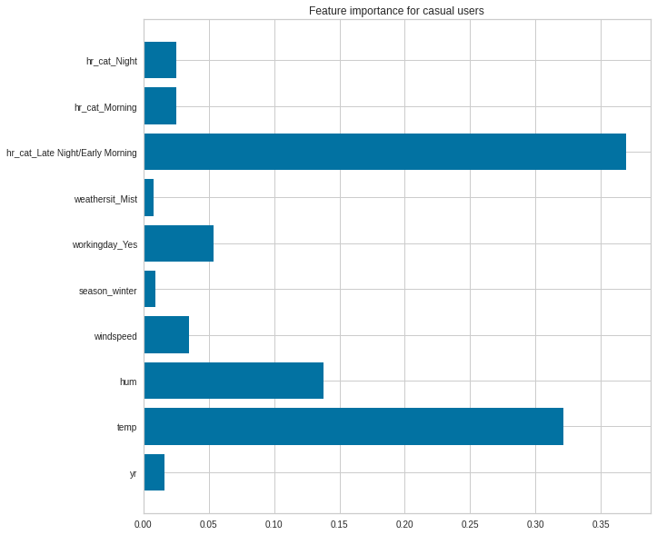

```python
#Plot feature importance
import matplotlib.pyplot as plt

plt.figure(figsize=(6,6))
plt.barh(X_train_cas.columns, rf_cas_tuned.feature_importances_)
plt.title('Feature importance for casual users')
plt.show()
```

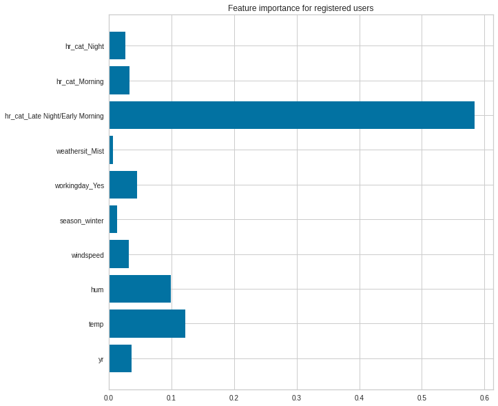

```python
plt.figure(figsize=(6,6))
plt.barh(X_train_reg.columns, rf_reg_tuned.feature_importances_)
plt.title('Feature importance for registered users')
plt.show()
```

## PyCaret: Predict *casual* and *registered* separately

#### PyCaret is an easier and faster way to build machine learning models and will allow us to compare the performance of different models, keeping the observations from the MVM models in mind. We will use PyCaret to predict casual and registered users separately.

#### We will be testing our predictive models on the same test dataset in order to compare the results.

#### We will also try to build a predictive model only for *cnt* and compare the results.

### Casual users

We decide to ignore the same features as the ones we dropped in the MVM

```python
models = compare_models(exclude = ['ransac'], n_select = 3, fold = 5, sort = "MAE")
```

|  | Model | MAE | MSE | RMSE | R2 | RMSLE | MAPE | TT (Sec) |
| --- | --- | --- | --- | --- | --- | --- | --- | --- |
| catboost | CatBoost Regressor | 12.0748 | 443.9956 | 21.0671 | 0.8214 | 0.6772 | 0.6817 | 2.770 |
| rf | Random Forest Regressor | 12.1466 | 443.7232 | 21.0619 | 0.8215 | 0.7011 | 0.7015 | 2.608 |
| lightgbm | Light Gradient Boosting Machine | 12.1937 | 454.5656 | 21.3189 | 0.8171 | 0.6785 | 0.6834 | 0.404 |
| et | Extra Trees Regressor | 12.3040 | 440.4107 | 20.9838 | 0.8228 | 0.7340 | 0.7451 | 2.482 |
| xgboost | Extreme Gradient Boosting | 12.3391 | 460.8391 | 21.4594 | 0.8146 | 0.6982 | 0.7061 | 1.490 |
| gbr | Gradient Boosting Regressor | 13.0649 | 544.8161 | 23.3410 | 0.7808 | 0.6943 | 0.7161 | 0.722 |
| knn | K Neighbors Regressor | 13.7432 | 571.6618 | 23.9028 | 0.7700 | 0.7583 | 0.8173 | 0.370 |
| dt | Decision Tree Regressor | 15.7911 | 731.2040 | 27.0381 | 0.7058 | 0.9266 | 1.0262 | 0.098 |
| huber | Huber Regressor | 16.8009 | 966.4236 | 31.0795 | 0.6113 | 0.7697 | 0.9310 | 0.126 |
| lar | Least Angle Regression | 17.0162 | 1012.9497 | 31.8207 | 0.5926 | 0.7647 | 0.8757 | 0.092 |
| ridge | Ridge Regression | 17.0177 | 1013.2444 | 31.8253 | 0.5925 | 0.7647 | 0.8756 | 0.094 |
| lr | Linear Regression | 17.0193 | 1013.3142 | 31.8265 | 0.5924 | 0.7648 | 0.8757 | 1.624 |
| br | Bayesian Ridge | 17.0203 | 1013.7729 | 31.8337 | 0.5923 | 0.7647 | 0.8756 | 0.070 |
| ada | AdaBoost Regressor | 19.9411 | 1545.8905 | 39.3106 | 0.3781 | 0.8280 | 0.7809 | 0.610 |
| omp | Orthogonal Matching Pursuit | 22.0965 | 1899.0303 | 43.5746 | 0.2362 | 0.9508 | 1.1603 | 0.090 |
| par | Passive Aggressive Regressor | 30.1622 | 5232.9321 | 66.9792 | -1.1271 | 1.0424 | 1.3146 | 0.074 |
| en | Elastic Net | 30.3338 | 2863.3322 | 53.5089 | -0.1518 | 1.4595 | 2.1017 | 0.088 |
| lasso | Lasso Regression | 30.7231 | 2897.6075 | 53.8282 | -0.1656 | 1.4838 | 2.1593 | 0.094 |
| llar | Lasso Least Angle Regression | 30.7231 | 2897.6075 | 53.8282 | -0.1656 | 1.4838 | 2.1593 | 0.096 |
| dummy | Dummy Regressor | 30.7231 | 2897.6075 | 53.8282 | -0.1656 | 1.4838 | 2.1593 | 0.058 |

[output not shown]

[output cut: 10 more lines]

[output not shown]

### Stacking

```python
stacked_cas = stack_models(models, fold = 10, meta_model = model_cas, choose_better = True)
```

| Fold | MAE | MSE | RMSE | R2 | RMSLE | MAPE |
| --- | --- | --- | --- | --- | --- | --- |
| 0 | 12.1337 | 438.8141 | 20.9479 | 0.8217 | 0.6875 | 0.6905 |
| 1 | 11.5421 | 382.9231 | 19.5684 | 0.8460 | 0.6660 | 0.6471 |
| 2 | 12.6233 | 484.8411 | 22.0191 | 0.8084 | 0.6955 | 0.6891 |
| 3 | 11.0948 | 382.1207 | 19.5479 | 0.8493 | 0.6490 | 0.6318 |
| 4 | 12.5950 | 470.4703 | 21.6903 | 0.7947 | 0.6919 | 0.7266 |
| 5 | 11.6271 | 416.2174 | 20.4014 | 0.8340 | 0.6693 | 0.7007 |
| 6 | 12.0854 | 456.9055 | 21.3753 | 0.8198 | 0.6858 | 0.6747 |
| 7 | 11.4512 | 381.4877 | 19.5317 | 0.8486 | 0.6751 | 0.7093 |
| 8 | 11.4815 | 365.6132 | 19.1210 | 0.8497 | 0.6840 | 0.6790 |
| 9 | 11.9047 | 421.3501 | 20.5268 | 0.8352 | 0.6860 | 0.7018 |
| Mean | 11.8539 | 420.0743 | 20.4730 | 0.8307 | 0.6790 | 0.6851 |
| Std | 0.4797 | 39.6665 | 0.9648 | 0.0181 | 0.0135 | 0.0270 |

[output not shown]

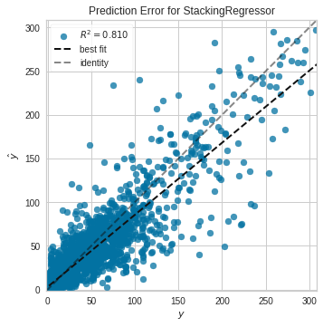

```
INFO:logs:Visual Rendered Successfully
INFO:logs:plot_model() succesfully completed......................................
```

```python
plot_model(stacked_cas, plot = 'error')
```

### Registered users

```python
models = compare_models(exclude = ['ransac'], n_select = 3, fold = 5, sort = "MAE")
```

|  | Model | MAE | MSE | RMSE | R2 | RMSLE | MAPE | TT (Sec) |
| --- | --- | --- | --- | --- | --- | --- | --- | --- |
| catboost | CatBoost Regressor | 63.6384 | 10548.1615 | 102.6848 | 0.5409 | 0.6741 | 0.7752 | 2.538 |
| lightgbm | Light Gradient Boosting Machine | 64.6346 | 10766.3058 | 103.7420 | 0.5314 | 0.6775 | 0.7975 | 0.182 |
| xgboost | Extreme Gradient Boosting | 65.3606 | 11015.3064 | 104.9310 | 0.5206 | 0.6998 | 0.8090 | 1.462 |
| rf | Random Forest Regressor | 65.5905 | 11277.8310 | 106.1708 | 0.5092 | 0.7007 | 0.8116 | 2.672 |
| gbr | Gradient Boosting Regressor | 66.8152 | 11396.0080 | 106.7445 | 0.5039 | 0.6907 | 0.8380 | 0.746 |
| et | Extra Trees Regressor | 68.0065 | 12266.2581 | 110.7487 | 0.4660 | 0.7396 | 0.8386 | 2.488 |
| knn | K Neighbors Regressor | 69.4924 | 12341.2297 | 111.0734 | 0.4628 | 0.7415 | 0.8963 | 0.356 |
| huber | Huber Regressor | 71.2973 | 13826.5053 | 117.5760 | 0.3981 | 0.7860 | 0.9558 | 0.140 |
| br | Bayesian Ridge | 72.0377 | 13051.2728 | 114.2334 | 0.4319 | 0.8005 | 1.0164 | 0.072 |
| ridge | Ridge Regression | 72.0404 | 13048.1316 | 114.2197 | 0.4320 | 0.8006 | 1.0159 | 0.066 |
| lr | Linear Regression | 72.0446 | 13053.9834 | 114.2455 | 0.4317 | 0.8005 | 1.0171 | 0.066 |
| lar | Least Angle Regression | 72.1099 | 13039.6929 | 114.1825 | 0.4324 | 0.8011 | 1.0131 | 0.070 |
| ada | AdaBoost Regressor | 74.0274 | 12078.2578 | 109.8959 | 0.4742 | 0.7625 | 1.1009 | 0.558 |
| omp | Orthogonal Matching Pursuit | 79.5738 | 16087.2950 | 126.8308 | 0.2997 | 0.8484 | 1.2049 | 0.064 |
| dt | Decision Tree Regressor | 87.5311 | 20510.2892 | 143.1769 | 0.1073 | 0.9156 | 1.0892 | 0.104 |
| par | Passive Aggressive Regressor | 107.7546 | 23087.7886 | 151.3889 | -0.0057 | 1.1669 | 2.3184 | 0.078 |
| en | Elastic Net | 111.5177 | 25627.9684 | 160.0839 | -0.1157 | 1.4172 | 4.8274 | 0.068 |
| llar | Lasso Least Angle Regression | 111.5177 | 25627.9671 | 160.0839 | -0.1157 | 1.4172 | 4.8274 | 0.066 |
| lasso | Lasso Regression | 111.5177 | 25627.9684 | 160.0839 | -0.1157 | 1.4172 | 4.8274 | 0.066 |
| dummy | Dummy Regressor | 111.5177 | 25627.9671 | 160.0839 | -0.1157 | 1.4172 | 4.8274 | 0.066 |

[output not shown]

### Bagging

```python
bagged_reg = ensemble_model(tuned_reg, fold = 10, choose_better = True)
```

| Fold | MAE | MSE | RMSE | R2 | RMSLE | MAPE |
| --- | --- | --- | --- | --- | --- | --- |
| 0 | 65.9616 | 11310.7214 | 106.3519 | 0.5154 | 0.6736 | 0.7692 |
| 1 | 64.1461 | 10421.2807 | 102.0847 | 0.5410 | 0.7051 | 0.8517 |
| 2 | 63.1378 | 10241.4884 | 101.2002 | 0.5593 | 0.6701 | 0.7653 |
| 3 | 62.4883 | 10167.1166 | 100.8321 | 0.5495 | 0.6777 | 0.7914 |
| 4 | 60.9351 | 9871.9109 | 99.3575 | 0.5652 | 0.6598 | 0.7562 |
| 5 | 63.1281 | 10829.2629 | 104.0637 | 0.5349 | 0.6611 | 0.7606 |
| 6 | 65.9121 | 11317.7689 | 106.3850 | 0.5202 | 0.6733 | 0.7952 |
| 7 | 62.9421 | 10623.7360 | 103.0715 | 0.5334 | 0.6708 | 0.7785 |
| 8 | 63.4031 | 10797.8038 | 103.9125 | 0.5338 | 0.6934 | 0.8150 |
| 9 | 60.5220 | 9706.6385 | 98.5223 | 0.5654 | 0.6702 | 0.7785 |
| Mean | 63.2576 | 10528.7728 | 102.5781 | 0.5418 | 0.6755 | 0.7862 |
| Std | 1.6961 | 523.2497 | 2.5491 | 0.0168 | 0.0132 | 0.0276 |

[output not shown]

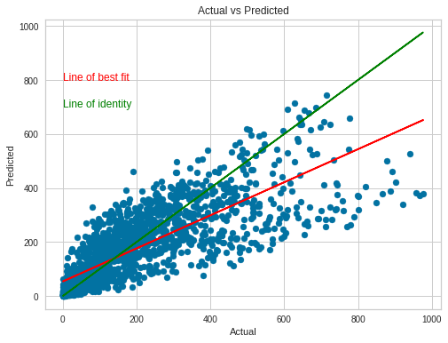

```python
#Plot predicted vs actual

plt.figure(figsize = (8, 6))
plt.scatter(unseen_predictions2['cnt'], unseen_predictions2['Pred_cnt'])
plt.xlabel('Actual')
plt.ylabel('Predicted')
plt.title('Actual vs Predicted')
#Add line of best fit
m, b = np.polyfit(unseen_predictions2['cnt'], unseen_predictions2['Pred_cnt'], 1)
plt.plot(unseen_predictions2['cnt'], m*unseen_predictions2['cnt'] + b, color = 'red')
#Add line of identity
plt.plot(unseen_predictions2['cnt'], unseen_predictions2['cnt'], color = 'green')
#Add labels
plt.text(0, 800, 'Line of best fit', color = 'red')
plt.text(0, 700, 'Line of identity', color = 'green')
plt.show()
```

```python
print("Mean absolute error: ",round(mean_absolute_error(unseen_predictions2['cnt'],unseen_predictions2['Pred_cnt']),3))
```

```
Mean absolute error:  70.52
```

## PyCaret: Predict *cnt*

```python
models = compare_models(exclude = ['ransac'], n_select = 3, fold = 5, sort = "MAE")
```

|  | Model | MAE | MSE | RMSE | R2 | RMSLE | MAPE | TT (Sec) |
| --- | --- | --- | --- | --- | --- | --- | --- | --- |
| catboost | CatBoost Regressor | 70.9074 | 12377.0986 | 111.2322 | 0.6245 | 0.6569 | 0.7553 | 2.600 |
| lightgbm | Light Gradient Boosting Machine | 71.8465 | 12509.1914 | 111.8296 | 0.6205 | 0.6608 | 0.7802 | 0.258 |
| xgboost | Extreme Gradient Boosting | 72.7611 | 12925.0178 | 113.6708 | 0.6079 | 0.6824 | 0.7881 | 1.460 |
| rf | Random Forest Regressor | 73.4329 | 13201.6365 | 114.8852 | 0.5995 | 0.6908 | 0.8081 | 2.654 |
| gbr | Gradient Boosting Regressor | 75.1587 | 13526.8020 | 116.2913 | 0.5896 | 0.6766 | 0.8239 | 1.216 |
| et | Extra Trees Regressor | 76.0316 | 14428.6330 | 120.0919 | 0.5622 | 0.7293 | 0.8389 | 2.508 |
| knn | K Neighbors Regressor | 78.2871 | 14915.4282 | 122.1142 | 0.5475 | 0.7274 | 0.8676 | 0.384 |
| huber | Huber Regressor | 83.5613 | 16890.4989 | 129.9489 | 0.4876 | 0.7699 | 0.9777 | 0.142 |
| br | Bayesian Ridge | 84.4381 | 16403.2166 | 128.0613 | 0.5024 | 0.7781 | 0.9981 | 0.072 |
| lar | Least Angle Regression | 84.4398 | 16397.6481 | 128.0397 | 0.5026 | 0.7782 | 0.9973 | 0.114 |
| ridge | Ridge Regression | 84.4402 | 16399.6213 | 128.0473 | 0.5025 | 0.7782 | 0.9976 | 0.100 |
| lr | Linear Regression | 84.4660 | 16411.8849 | 128.0952 | 0.5021 | 0.7780 | 0.9984 | 0.110 |
| ada | AdaBoost Regressor | 85.6419 | 15871.5948 | 125.9617 | 0.5186 | 0.7626 | 1.1356 | 1.294 |
| omp | Orthogonal Matching Pursuit | 94.3932 | 20820.4557 | 144.2837 | 0.3683 | 0.8387 | 1.1918 | 0.110 |
| dt | Decision Tree Regressor | 95.4193 | 23116.0457 | 152.0322 | 0.2983 | 0.8912 | 1.0815 | 0.102 |
| par | Passive Aggressive Regressor | 113.5528 | 28520.3588 | 168.3784 | 0.1351 | 1.0129 | 1.4701 | 0.076 |
| en | Elastic Net | 138.6205 | 36959.9276 | 192.2408 | -0.1212 | 1.4365 | 5.1658 | 0.106 |
| llar | Lasso Least Angle Regression | 138.6205 | 36959.9268 | 192.2408 | -0.1212 | 1.4365 | 5.1658 | 0.100 |
| lasso | Lasso Regression | 138.6205 | 36959.9276 | 192.2408 | -0.1212 | 1.4365 | 5.1658 | 0.096 |
| dummy | Dummy Regressor | 138.6205 | 36959.9268 | 192.2408 | -0.1212 | 1.4365 | 5.1658 | 0.060 |

[output not shown]

### Stacking

```python
stacked_cnt = stack_models(models, fold = 10, meta_model = model_cnt)
```

| Fold | MAE | MSE | RMSE | R2 | RMSLE | MAPE |
| --- | --- | --- | --- | --- | --- | --- |
| 0 | 71.6609 | 12784.6185 | 113.0691 | 0.6278 | 0.6672 | 0.7503 |
| 1 | 69.6842 | 12419.0259 | 111.4407 | 0.6199 | 0.6450 | 0.7321 |
| 2 | 71.3931 | 12616.6713 | 112.3240 | 0.6315 | 0.6572 | 0.7256 |
| 3 | 75.4990 | 14138.8989 | 118.9071 | 0.5949 | 0.6710 | 0.8111 |
| 4 | 72.2969 | 12870.9055 | 113.4500 | 0.6172 | 0.6697 | 0.7457 |
| 5 | 67.6479 | 11069.5766 | 105.2121 | 0.6431 | 0.6554 | 0.7937 |
| 6 | 67.0557 | 10764.5594 | 103.7524 | 0.6584 | 0.6498 | 0.7697 |
| 7 | 69.3673 | 11764.8007 | 108.4657 | 0.6278 | 0.6421 | 0.7267 |
| 8 | 73.1487 | 12650.9839 | 112.4766 | 0.6018 | 0.6560 | 0.7590 |
| 9 | 73.8517 | 13872.9376 | 117.7834 | 0.5905 | 0.6867 | 0.8212 |
| Mean | 71.1605 | 12495.2978 | 111.6881 | 0.6213 | 0.6600 | 0.7635 |
| Std | 2.5728 | 1021.3057 | 4.5898 | 0.0202 | 0.0129 | 0.0329 |

[output not shown]

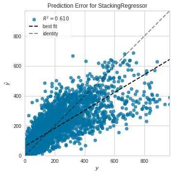

```
INFO:logs:Visual Rendered Successfully
INFO:logs:plot_model() succesfully completed......................................
```

```python
plot_model(stacked_cnt, plot = 'error')
```

```python
print("Mean absolute error (registered and casual, separated): ",round(mean_absolute_error(fin['cnt'],fin['Pred_cnt']),3))
```

```
Mean absolute error (registered and casual, separated):  70.52
```

```python
print("Mean absolute error (only total users): ",round(mean_absolute_error(fin['cnt'],fin['Label']),3))
```

```
Mean absolute error (only total users):  71.803
```

## **Recommendations (from a technical perspective)**

1. Execute two separate models as different factors influence registered users and casual users to bike in Washington D.C.
2. More information to improve the model: registration costs, usage of other modes of transport in the city, location of bike stations, traffic and frequency of usage on the same day.

## **Summary**

1. The most preferred *feeling* temperature of users is between 31 and 35 degrees Celsius to use the bike service.
2. Most users use the bike services around 8 in the morning and around 5-6 in the afternoon. This indicates a higher uptake of the service during rush hours.
3. The service is used consistently over all days of the week, i.e. there is no preference to bike only during the weekdays or only during the weekends.
4. Usage **definitely** decreases as the weather becomes "less clear"
5. More granular data with more information will help improve the predictive power of the model.